# SKOC62: Research Methods in Strategic Communication VT25

Quantitative methods workshops 1 — 4

Author

nils.holmberg@iko.lu.se

## 0.1 Introduction

[interactive chart not shown]

- SPSS download student version: [link](https://www.lu.se/studera/livet-som-student/it-tjanster-support-och-driftinfo/programvara)
- SPSS canvas data file: [link](https://canvas.education.lu.se/courses/21228/files/3453815/download?download_frd=1)
- SPSS tutorial in english: [link](https://www.lse.ac.uk/Methodology/Software-tutorials/SPSS-tutorials)
- SPSS tutorial in swedish: [link](https://www.graduateschool.sam.lu.se/current-students/student-links-and-resources/methods-resources-thesis-writing/how-use-spss)
- Observe that instructions become less and less detailed as you work your way through the tasks.
- Open SPSS. Log into the course website at Canvas. Download the file Communicative Organizations Database.
- **SUPER IMPORTANT!! Save your data file and all changes so you can use it for the following workshops! Also save your output files or copy paste relevant parts to another document if you want to remember what you did in the previous workshop!**

# 1 Workshop: Descriptive statistics

- link

# 2 Workshop: Data transformation

- link

# 3 Workshop: Bivariate analysis

## 3.1 Univariate analysis

1. Create a new summative index `infoaccess_index` using the variables 6-11: `info_work`, `info_org`, `info_vision`, `info_change`, `info_intracomm` and `info_mgmttrust`. Note central tendency, dispersion and normal distribution.

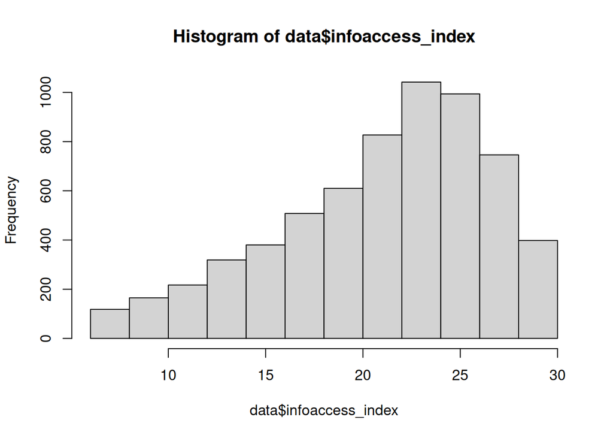

```
   Min. 1st Qu.  Median    Mean 3rd Qu.    Max.    NA's
   6.00   18.00   23.00   21.49   26.00   30.00    1767
```

2. Take a look at the following variables: `Age` in years (see previous workshop), `Gender`, `Role`, and `Org_type`. Note the dispersion, central tendency and normal distribution of the variables **as applicable**. Are the variables quantitative (ratio/interval) or qualitative (nominal/ordinal)?
3. How can we think about the possible effects that the variables in 3.1b can have on the index in 3.1a? What does the index measure?

## 3.2 Bivariate analysis

1. Perform bivariate analyses for each of the variables in 3.1b and the `infoaccess_index`. Use compare means to compare with qualitative variables; use correlate to compare with quantitative variables. (NB: For tests of statistical significance when comparing means, please follow instructions given during the workshop (i.e. independent samples t-test and one-way ANOVA).)
2. Now perform bivariate analyses for each of the variables in 3.1b pairwise (i.e. compare them with each other, using cross tables, compare means, or correlation **as applicable**). Note any significant relationships.

## 3.3 Creating dummy variables

1. Recode `Gender` to a variable with only two categories, Female=1 and Male=0. Compare it with the original variable to make sure you coded correctly. Name it `dummy_gender`.

```
Female   Male  Other   <NA>
  4262   2179     19   1631
```

```
 Factor w/ 3 levels "Female","Male",..: 1 2 1 1 1 1 2 2 2 1 ...
```

```
[1] "Female" "Male"   "Other"
```

```
  _male _female    <NA>
   2179    4262    1650
```

2. Recode Role into three separate dummy variables as follows: Create three new variables named `dummy_manager`, `dummy_communicator`, and `dummy_coworker`. `dummy_manager` should have the value 1 for manager and 0 for all other values in the old variable. `dummy_communicator` should have the vale 1 for communicator and 0 for all other values in the old variable. `dummy_coworker` should have the value 1 for coworkers and 0 for all other values in the old variable. Compare the dummy variables with the original variable `Role` to make sure you coded correctly. Note that you will use these variables during the next workshop!

```
                    Manager                    Coworker
                       1520                        6068
Communicator or equivalent                         <NA>
                        499                           4
```

```
[1] "Manager"                     "Coworker"
[3] "Communicator or equivalent "
```

**THAT’S IT FOR TODAY! REMEMBER TO SAVE YOUR DATA AND OUTPUT FILES (THOSE ARE TWO DIFFERENT OPERATIONS)!**

# 4 Workshop: Multivariate analysis

- link
- [osm-comm website](https://cca-cce.github.io/osm-comm/)